# Obtendo distribuições posteriores conjuntas via INLA

Fernando Mayer

2018-09-18 Última atualização: 2019-11-14

# 1 Introdução

Este documento tem a finalidade de exemplificar a obtenção de distribuições posteriores conjuntas via “Integrated Nested Laplace Approximation” (INLA), utilizando o pacote de mesmo nome no R.

Como exemplo de motivação é utilizada uma regressão logística, onde o objetivo é estimar, além dos parâmetros $\beta_0$ e $\beta_1$, uma outra medida que é uma função linear destes dois parâmetros.

Do ponto de vista frequentista, a estimativa pontual de uma função linear de parâmetros é obtida de maneira direta. No entanto, para se obter uma estimativa do erro-padrão dessa estimativa, é necessário recorrer à teoria assintótica para se obter a distribuição dessa função.

No caso bayesiano, a distribuição conjunta dos parâmetros que formam essa função pode ser utilizada de imediato para se obter tanto estimativas pontuais quanto medidas de variação.

A obtenção da distribuição conjunta dos parâmetros de um modelo pode ser obtida facilmente quando se realiza a inferância bayesiana via métodos de simulação como MCMC. No entanto, quando a inferência é realizada através de métodos de aproximação, como é o caso do INLA, a obtenção de posteriores conjuntas não é direta.

Portanto, aqui serão mostrados três métodos de obtenção de estimativas pontuais e de variação para os parâmetros de uma regressão logística e para uma função linear destes parâmetros: método da máxima verossimilhança, método bayesiano via MCMC e método bayesiano via INLA.

# 2 Dados

Os dados utilizados aqui como exemplo são do livro de Kinas and Andrade (2010), capítulo 8, e são referentes ao comprimento e maturidade de fêmeas do peixe-galo (*Zenopsis conchifera*).

```r
Classe <- paste0("[", seq(10, 50, 5), ",", seq(15, 55, 5), ")")
Total <- c(97, 89, 73, 69, 62, 55, 59, 60, 40)
Maturas <- c(4, 2, 9, 52, 62, 53, 59, 60, 40)
dados <- data.frame(Classe, Total, Maturas)
```

Table 2.1: Número total e de fêmeas maturas por classe de comprimento (cm)

| Classe | Total | Maturas |
| --- | --- | --- |
| [10,15) | 97 | 4 |
| [15,20) | 89 | 2 |
| [20,25) | 73 | 9 |
| [25,30) | 69 | 52 |
| [30,35) | 62 | 62 |
| [35,40) | 55 | 53 |
| [40,45) | 59 | 59 |
| [45,50) | 60 | 60 |
| [50,55) | 40 | 40 |

Com estes dados podemos calcular então a proporção de fêmeas maturas (`Prop`) e definir o ponto médio de cada classe (`PM`) como o valor de comprimento. Além disso, vamos centralizar o ponto médio (`PMc`) para facilidade de interpretação. A tabela de dados completa fica dessa forma:

```r
Prop <- Maturas/Total
PM <- seq(10, 50, 5) + 2.5
PMc <- PM - mean(PM)
dados <- cbind(dados, Prop, PM, PMc)
```

Table 2.2: Tabela de dados completa

| Classe | Total | Maturas | Prop | PM | PMc |
| --- | --- | --- | --- | --- | --- |
| [10,15) | 97 | 4 | 0.0412371 | 12.5 | -20 |
| [15,20) | 89 | 2 | 0.0224719 | 17.5 | -15 |
| [20,25) | 73 | 9 | 0.1232877 | 22.5 | -10 |
| [25,30) | 69 | 52 | 0.7536232 | 27.5 | -5 |
| [30,35) | 62 | 62 | 1.0000000 | 32.5 | 0 |
| [35,40) | 55 | 53 | 0.9636364 | 37.5 | 5 |
| [40,45) | 59 | 59 | 1.0000000 | 42.5 | 10 |
| [45,50) | 60 | 60 | 1.0000000 | 47.5 | 15 |
| [50,55) | 40 | 40 | 1.0000000 | 52.5 | 20 |

Através do gráfico ao lado, podemos verificar que é razoável a suposição de que a proporção de fêmeas maturas aumenta conforme o tamanho.

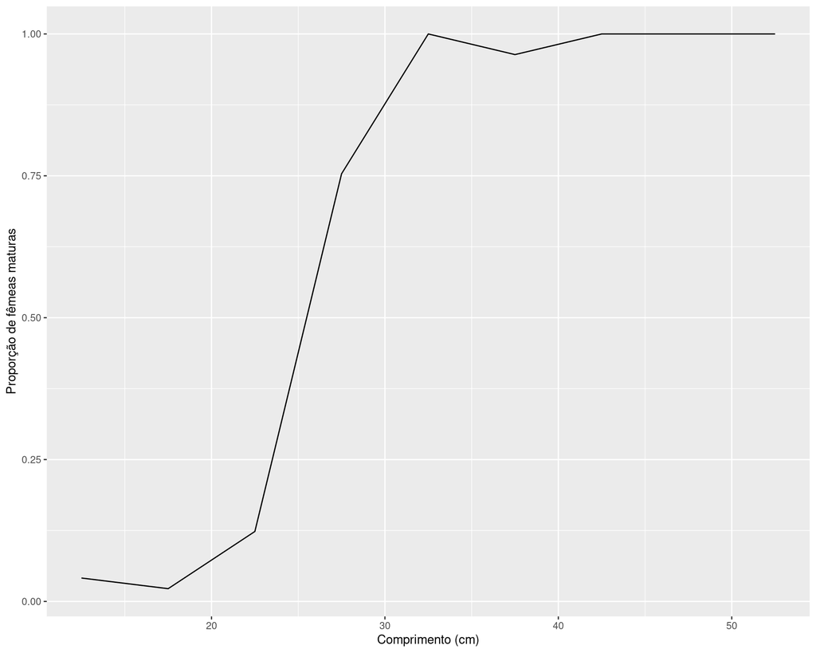

Figure 2.1: Proporção de fêmeas maturas por comprimento.

```r
library(ggplot2)
ggplot(dados, aes(PM, Prop)) + geom_line() +
    xlab("Comprimento (cm)") +
    ylab("Proporção de fêmeas maturas")
```

Normalmente, existe o interesse em se determinar o “tamanho de primeira maturação” das fêmeas, que geralmente é o comprimento em que 50% das fêmeas estão maturas (LT-50). A inspeção visual do gráfico já da uma ideia de qual seria esse comprimento. No entanto, precisamos modelar esses dados e obter uma forma mais robusta de se obter essa estimativa.

# 3 Modelo

Seja $p_i$ a probabilidade de uma fêmea estar matura na classe de comprimento $i$. Temos ao total $n_i$ fêmeas, das quais $y_i$ são maturas. Dessa forma, é natural que a variável aleatória $Y_i$ (número de fêmeas maturas) seja considerada como proveniente de uma distribuição binomial, ou seja $Y_i \sim \text{Bin}(n_i, p_i)$.

Com isso, podemos assumir um modelo logístico para relacionar a proporção de fêmeas maturas com o comprimento, através das seguinte relação:

$$\log \left( \frac{p_i}{1 - p_i} \right) = \beta_0 +
\beta_1 (x_i - \bar{x})$$

Para encontrarmos o LT-50, basta lembrar que esse é o comprimento em que 50% das fêmeas estão maturas. Portanto, fazemos $p_i = 0.5$ na equação acima e resolvemos para $x_i$, que agora chamaremos de LT-50. Portanto, temos que o LT-50 pode ser estimado com:

$$\begin{align*}
\log \left( \frac{0.5}{1 - 0.5} \right) &= \beta_0 +
\beta_1 (\text{LT-50} - \bar{x}) \\
0 &= \beta_0 + \beta_1 (\text{LT-50} - \bar{x}) \\
-\frac{\beta_0}{\beta_1} &= \text{LT-50} - \bar{x} \\
& \Rightarrow \text{LT-50} = -\frac{\beta_0}{\beta_1} + \bar{x}
\end{align*}$$

# 4 Métodos de estimação

## 4.1 Método da máxima verossimilhança

As estimativas pontuais dos parâmetros do modelo pelo método da máxima verossimilhança serão obtidas através de um GLM, especificando a família de distribuição da variável resposta como binomial e função de ligação *logit*.

```r
m.glm <- glm(Prop ~ PMc, data = dados, weights = Total,
             family = binomial(link = "logit"))
summary(m.glm)
#
# Call:
# glm(formula = Prop ~ PMc, family = binomial(link = "logit"),
#     data = dados, weights = Total)
#
# Deviance Residuals:
#     Min       1Q   Median       3Q      Max
# -2.3136  -0.7782   0.1192   1.0183   3.1793
#
# Coefficients:
#             Estimate Std. Error z value Pr(>|z|)
# (Intercept)  2.89039    0.33099   8.733   <2e-16 ***
# PMc          0.41010    0.03839  10.681   <2e-16 ***
# ---
# Signif. codes:  0 '***' 0.001 '**' 0.01 '*' 0.05 '.' 0.1 ' ' 1
#
# (Dispersion parameter for binomial family taken to be 1)
#
#     Null deviance: 625.993  on 8  degrees of freedom
# Residual deviance:  27.295  on 7  degrees of freedom
# AIC: 48.008
#
# Number of Fisher Scoring iterations: 6
```

Através deste resultado, obtemos as estimativas pontuais e o erro-padrão para cada parâmetro. Com isso, já temos ideia da precisão dessas estimativas.

Para calcular o LT-50, basta então aplicar a equação já obtida acima.

```r
## Estimativas pontuais
b0.glm <- coef(m.glm)[1]
b1.glm <- coef(m.glm)[2]

## Cálculo do LT50
(lt50.glm <- -(b0.glm/b1.glm) + mean(dados$PM))
# (Intercept)
#    25.45201
```

Assim, obtemos uma estimativa do LT-50 como sendo 25.45. No entanto, não sabemos a precisão dessa estimativa pois para calcular o erro-padrão associado precisamos da distribuição assintótica do LT-50.

Mas antes de obtê-la, vamos analisar a distribuição assintótica de $\beta_0$ e $\beta_1$.

```r
## Variâncias dos parâmetros
varcov <- vcov(m.glm)
var.b0 <- vcov(m.glm)[1,1]
var.b1 <- vcov(m.glm)[2,2]

## Distribuição assintótica de b0
x.b0 <- seq(-3, 3, length = 100) + b0.glm
dens.b0 <- dnorm(x.b0, mean = b0.glm, sd = sqrt(var.b0))
## Distribuição assintótica de b1
x.b1 <- seq(-2, 2, length = 100) + b1.glm
dens.b1 <- dnorm(x.b1, mean = b1.glm, sd = sqrt(var.b1))
```

Gráficos com as distribuiçãos assintoticas dos parâmetros do modelo logístico 4.1.

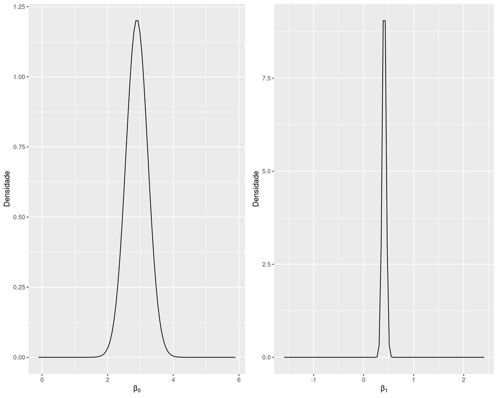

Figure 4.1: Distribuição assintótica dos betas.

```r
library(gridExtra)
p1 <- qplot(x.b0, dens.b0, geom = "line",
            xlab = expression(beta[0]), ylab = "Densidade")
p2 <- qplot(x.b1, dens.b1, geom = "line",
            xlab = expression(beta[1]), ylab = "Densidade")
grid.arrange(p1, p2, ncol = 2)
```

**Resultados assintóticos**

Dentre as várias propriedades de um estimador, duas são fundamentais: a **consistência** e a **eficiência**. A consistência se refere ao fato de que um estimador deve deve convergir para o verdadeiro valor do parâmetro, a medida que o tamanho da amostra aumenta. Já a eficiência diz respeito à variância assintótica de um estimador. Quando dois (ou mais) estimadores não viesados são comparados, o melhor (mais eficiente) é aquele que possui a menor variância possível. Também podemos dizer que um estimador é eficiente se sua variância atinge um certo limite, ou a mínima variância possível.

Os estimadores de máxima verossimilhança (EMV) possuem estas duas propriedades: são consistentes e eficientes. Isso significa que, à medida que o tamanho da amostra aumenta, a estimativa pontual fica cada vez mais próxima do verdadeiro valor, e a variância dessa estimativa é a menor possível entre todos os estimadores.

Formalizando, dizemos que $\tau(\hat\theta)$ é um estimador consistente para $\tau(\theta)$ se

$$\lim_{n \to \infty} P[|\tau(\hat\theta) - \tau(\theta)| \geq \epsilon] = 0$$

para $\epsilon > 0$. Note que $\tau(\cdot)$ é uma função qualquer (diferenciável) de $\theta$.

Como mencionado anteriormente, podemos definir uma “cota” ou “limite” inferior que a variância de um estimador deve atingir para ser considerado um estimador eficiente. Esse limite inferior é o **Limite Inferior de Cramér-Rao** (LICR), definido por (ver Casella and Berger 2011, 299–301):

$$Var[\tau(\hat\theta)] \geq \frac{[\tau'(\theta)]^2}{I_E(\theta)}$$

onde $\tau'(\theta) = \frac{\partial \tau(\theta)}{\partial\theta}$, e

$$I_E(\theta) = E \left[ \left(\frac{\partial l(\theta)}{\partial \theta}
\right)^2 \right] =
-E \left[ \frac{\partial^2 l(\theta)}{\partial \theta^2} \right]$$

é a **Informação de Fisher esperada**. Assim, se a variância de um estimador for igual ao LICR, então dizemos que ele é eficiente (e todos os EMVs são).

De acordo com o LICR, existe uma variância assintótica ótima. Com isso, podemos definir que a distribuição assintótica de $\tau(\hat\theta)$ é

$$\sqrt{n}[\tau(\hat\theta) - \tau(\theta)] \quad \rightarrow \quad
N(0, V[\tau(\theta)])$$

onde $V[\tau(\theta)]$ é o LICR. Esse resultado nos diz então que o EMV $\tau(\hat\theta)$ é um estimador consistente e assintoticamente eficiente de $\tau(\theta)$. Também podemos escrever o mesmo resultado da seguinte forma:

$$\tau(\hat\theta) \sim N(\tau(\theta), V[\tau(\theta)])$$

Portanto, se um EMV é assintóticamente eficiente, sua variância assintótica é a variância do **Método Delta**. O Método Delta é uma generalização do **Teorema do Limite Central**, que diz o seguinte: se $\hat\theta$ satisfaz $\sqrt{n}[\hat\theta - \theta] \rightarrow N(0, \sigma^2)$, então dada uma função $\tau(\cdot)$ diferenciável em $\theta$, a distribuição de $\tau(\hat\theta)$ fica (ver Casella and Berger 2011, 217)

$$\sqrt{n}[\tau(\hat\theta) - \tau(\theta)] \quad \rightarrow \quad
N(0, \sigma^2 [\tau'(\theta)]^2)$$

Portanto, podemos utilizar o LICR como uma aproximação para a variância verdadeira do EMV. Mas, note que no LICR o denominador é a informação de Fisher **esperada**. No entanto, nem sempre conseguimos calcular a esperança para chegar nessa informação. Sendo assim, a partir do Método Delta e da variância assintótica do EMV, podemos aproximar a variância de $\tau(\hat\theta)$ por:

$$\begin{align*}
V[\tau(\hat\theta)|\theta] &= \frac{[\tau'(\theta)]^2}{I_E(\theta)} \\
&\approx \frac{[\tau'(\theta)]^2}{I_O(\theta)}
\end{align*}$$

onde

$$I_O(\theta) = - \frac{\partial^2 l(\theta)}{\partial \theta^2}$$

é a informação de Fisher **observada**. Segundo Casella and Berger (2011), o uso do *número de informações observado* é superior ao *número de informações esperado*, que é o utilizado no LICR. (Até aqui é um resumo de Casella and Berger (2011), pp. 421-423). Além disso, essa aproximação tem uma consequência computacional. No processo de otimização de uma função qualquer, é possível obter a matriz **Hessiana**, que contém as segundas derivadas parciais (numéricas) da função em relação a cada parâmetro, que é por si própria a matriz de informação de Fisher observada. Portanto, para obter as variâncias dos estimadores, basta inverter a matriz Hessiana e selecionar os elementos de sua diagonal.

Resumindo, temos então que a distribuição assintótica de $\tau(\hat\theta)$ é

$$\tau(\hat\theta) \sim N \left( \tau(\theta),
\frac{[\tau'(\theta)]^2}{I_O(\theta)} \right)$$

Note também que essa notação até aqui define todos os componentes de forma geral, ou seja para $\tau(\theta)$, sendo $\tau(\cdot)$ qualquer função diferenciável. Um caso particular (e mais simples) é quando $\tau(\theta) = \theta$, ou seja, estamos interessados no próprio valor do parâmetro e não em uma função dele. Nessas condições, temos que $\tau'(\theta) = 1$ e a distribuição do estimador $\tau(\hat\theta) = \hat\theta$ fica

$$\hat\theta \sim N \left( \theta,
\frac{1}{I_O(\theta)} \right)$$

Ou seja, a variância assintótica de $\hat\theta$ é simplesmente o inverso da informação de Fisher observada (ou o inverso da matriz Hessiana).

Outro detalhe importante é que o uso de $I_E(\theta)$ ou $I_O(\theta)$ geralmente leva ao mesmo resultado, pois se a segunda derivada da função em cada parâmetro não depender de $Y$, então $I_E(\theta) = I_O(\theta)$ (precisa de uma fonte aqui).

Para obter a distribuição assintotica do LT-50, precisamos:

1. Derivadas parciais da função $-\frac{\beta_0}{\beta_1}$ em relação a $\beta_0$ e $\beta_1$
2. Com isso calculamos a variância dessa função
3. Obtem a distribuição normal assintotica

```r
## Distribuição assintótica do LT50 ------------------------------------

## Derivadas parciais de -(b0/b1)
## Em relação a b0
D(expression(-b0/b1), "b0")
# -(1/b1)
b0.deriv <- - (1/b1.glm)
## Em relação a b1
D(expression(-b0/b1), "b1")
# b0/b1^2
b1.deriv <- b0.glm/b1.glm^2

## Vetor de derivadas
u.theta <- cbind(b0.deriv, b1.deriv)

## Variância de -(b0/b1)
lt50.var <- as.numeric(u.theta %*% varcov %*% t(u.theta))

## Distribuição assintótica de LT50
x.lt50 <- seq(-3, 3, length = 100) + lt50.glm
dens.lt50 <- dnorm(x.lt50, mean = lt50.glm, sd = sqrt(lt50.var))
```

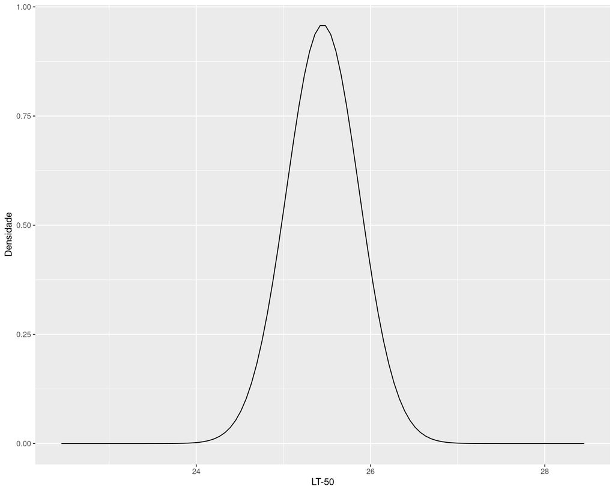

Figure 4.2: Distribuição assintótica do LT-50.

```r
qplot(x.lt50, dens.lt50, geom = "line",
      xlab = "LT-50", ylab = "Densidade")
```